# **Modeling Notebook**

## Linear Regression

```python
# Linear Regression
from sklearn.linear_model import LinearRegression


# Separate features and target variable
X = group_2_df_cleaned.drop(columns=["ACTUAL_WORK_IN_MINUTES"])  # All columns except the target
y = group_2_df_cleaned["ACTUAL_WORK_IN_MINUTES"]  # Target variable

# Identify categorical and numerical columns
categorical_cols = X.select_dtypes(include=['object']).columns
numeric_cols = X.select_dtypes(exclude=['object']).columns

# Preprocessing for numeric and categorical data
preprocessor = ColumnTransformer(
    transformers=[
        ('num', StandardScaler(), numeric_cols),
        ('cat', OneHotEncoder(drop='first', handle_unknown='ignore'), categorical_cols)
    ]
)

# Create a pipeline with preprocessing and Linear Regression
pipeline = Pipeline(steps=[
    ('preprocessor', preprocessor),
    ('regressor', LinearRegression())
])

# Split the data into training and testing sets
X_train, X_test, y_train, y_test = train_test_split(X, y, test_size=0.2, random_state=42)

# Fit the model
pipeline.fit(X_train, y_train)

# Make predictions on the test set
y_pred = pipeline.predict(X_test)

# Evaluate the model
mse = mean_squared_error(y_test, y_pred)
rmse = np.sqrt(mse)
r2 = r2_score(y_test, y_pred)

print("Mean Squared Error (MSE):", mse)
print("Root Mean Squared Error (RMSE):", rmse)
print("R-squared:", r2)
```

[output not shown]

```python
# Get the feature names after preprocessing
feature_names = numeric_cols.tolist() + pipeline.named_steps['preprocessor'].transformers_[1][1].get_feature_names_out(categorical_cols).tolist()

# Get the Lasso coefficients from the pipeline
lasso_coefficients = pipeline.named_steps['regressor'].coef_

# Combine feature names and coefficients into a DataFrame
coefficients_df = pd.DataFrame({'Feature': feature_names, 'Lasso Coefficient': lasso_coefficients})

# Filter out rows where the coefficient is zero
non_zero_coefficients_df = coefficients_df[coefficients_df['Lasso Coefficient'] != 0]

# Sort the DataFrame of non-zero coefficients in ascending order
sorted_coefficients_df = non_zero_coefficients_df.sort_values(by='Lasso Coefficient', ascending=True)
```

```python
# Display the top 10 rows
print("Top 10 rows contributing to reduction of Actual Work in Minutes (smallest coefficients):")
print(sorted_coefficients_df.head(10))

# Display the bottom 10 rows
print("Top 10 rows contributing to increase of Actual Work in Minutes (largest coefficients):")
print(sorted_coefficients_df.tail(10))
```

[output not shown]

## Lasso Regression

```python
# Separate features and target variable
X = group_2_df_cleaned.drop(columns=["ACTUAL_WORK_IN_MINUTES"])  # All columns except the target
y = group_2_df_cleaned["ACTUAL_WORK_IN_MINUTES"]  # Target variable

# Identify categorical and numerical columns
categorical_cols = X.select_dtypes(include=['object']).columns
numeric_cols = X.select_dtypes(exclude=['object']).columns

# Preprocessing for numeric data: Standard scaling
# Preprocessing for categorical data: One-hot encoding
preprocessor = ColumnTransformer(
    transformers=[
        ('num', StandardScaler(), numeric_cols),
        ('cat', OneHotEncoder(drop='first', handle_unknown='ignore'), categorical_cols)
    ]
)

# Create a pipeline with preprocessing and Lasso regression
pipeline = Pipeline(steps=[
    ('preprocessor', preprocessor),
    ('regressor', Lasso(alpha=0.01))  # Adjust alpha as needed
])
# Outside this modeling notebook, to save processing time, we implemented a Grid Search to find the best Alpha Score to use in the model. it was .01 as used above.

# Split the data
X_train, X_test, y_train, y_test = train_test_split(X, y, test_size=0.2, random_state=42)

# Fit the model
pipeline.fit(X_train, y_train)

# Make predictions and evaluate the model
y_pred = pipeline.predict(X_test)
mse = mean_squared_error(y_test, y_pred)
rmse = sqrt(mse)
r2 = r2_score(y_test, y_pred)

print("Mean Squared Error:", mse)
print("Lasso Coefficients:", pipeline.named_steps['regressor'].coef_)
print("R-squared:", r2)
print("Root Mean Squared Error:", rmse)
```

```
Mean Squared Error: 4504.047418556785
Lasso Coefficients: [ 2.72614046  0.05836964 12.34882933 ... -0.         32.10184085
 -0.        ]
R-squared: 0.4810641804437531
Root Mean Squared Error: 67.1122002213963
```

```python
# Get the feature names after preprocessing
feature_names = numeric_cols.tolist() + pipeline.named_steps['preprocessor'].transformers_[1][1].get_feature_names_out(categorical_cols).tolist()

# Get the Lasso coefficients from the pipeline
lasso_coefficients = pipeline.named_steps['regressor'].coef_

# Combine feature names and coefficients into a DataFrame
coefficients_df = pd.DataFrame({'Feature': feature_names, 'Lasso Coefficient': lasso_coefficients})

# Filter out rows where the coefficient is zero
non_zero_coefficients_df = coefficients_df[coefficients_df['Lasso Coefficient'] != 0]

# Sort the DataFrame of non-zero coefficients in ascending order
sorted_coefficients_df = non_zero_coefficients_df.sort_values(by='Lasso Coefficient', ascending=True)
```

**Top 10 Rows for Reduction and Increase of Actual Work in Minutes for Lasso Regression**

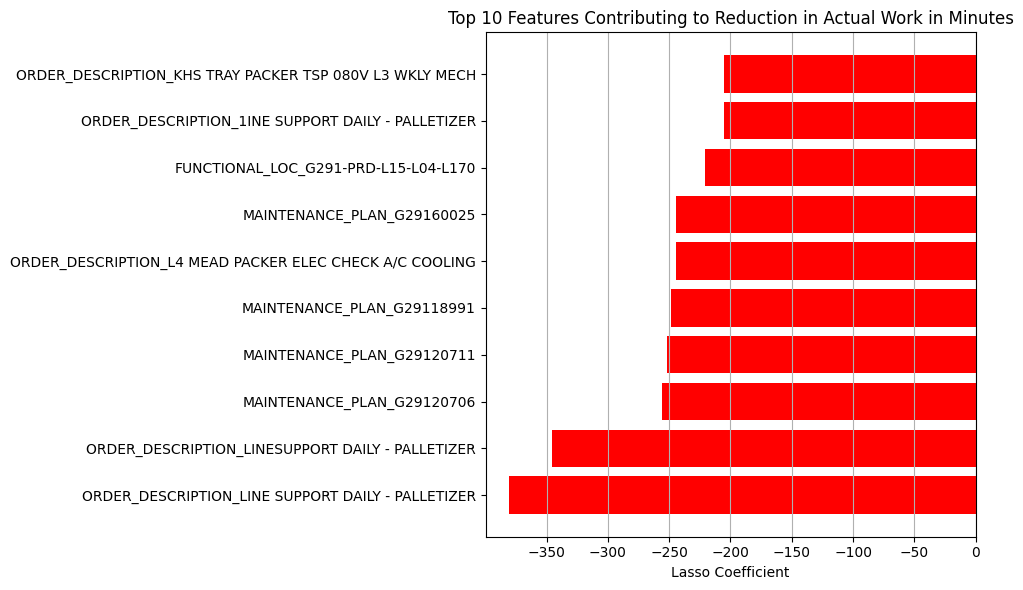

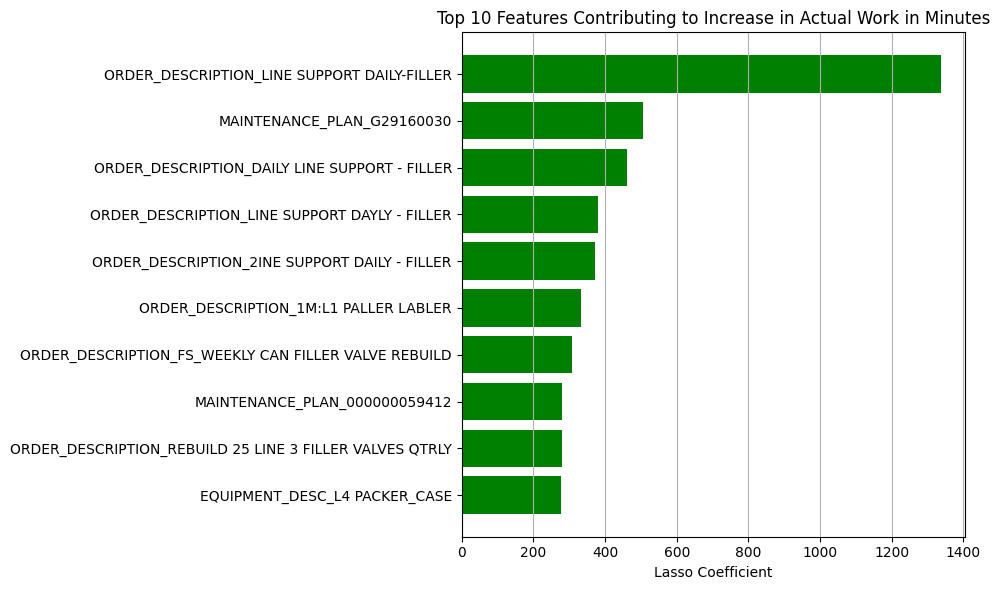

```python
# Plot the top 10 rows contributing to reduction and increase in Actual Work in Minutes

# Top 10 negative coefficients (contributing to reduction in Actual Work in Minutes)
top_10_negative = sorted_coefficients_df.head(10)

# Top 10 positive coefficients (contributing to increase in Actual Work in Minutes)
top_10_positive = sorted_coefficients_df.tail(10)

# Plotting the top 10 negative coefficients
plt.figure(figsize=(10, 6))
plt.barh(top_10_negative['Feature'], top_10_negative['Lasso Coefficient'], color='red')
plt.xlabel("Lasso Coefficient")
plt.title("Top 10 Features Contributing to Reduction in Actual Work in Minutes")
plt.grid(axis='x')
plt.tight_layout()
plt.show()

# Plotting the top 10 positive coefficients
plt.figure(figsize=(10, 6))
plt.barh(top_10_positive['Feature'], top_10_positive['Lasso Coefficient'], color='green')
plt.xlabel("Lasso Coefficient")
plt.title("Top 10 Features Contributing to Increase in Actual Work in Minutes")
plt.grid(axis='x')
plt.tight_layout()
plt.show()
```

**Interpretation:**

The features contributing to maintenance are features elated to the FILLER, LABLER, and different Maintenance Plans which may be planned.

- Industry expertise or knowledge of variables and correlation to production may be necessary for deeper analysis.

ORDER_DESCRIPTION_LINE SUPPORT DAILY-FILLER (1338.57)

- This order description shows a very high positive coefficient, when looking into the variable more, it represents two very long unplanned maintenances in the data, reducing or preventing this especilly lengthy maintenance it important.

MAINTENANCE_PLAN_G29160030 (504.93)

- This maintenance plan is associated with increased maintenance time, when looking further into the variable this is an unplanned maintenance happening in the MONZA plant and is corrective. The equipment descriptions for this are; L4 PALLETIZER_ELECPNEU T-TEK # 1, L4 PALLETIZER_ELECPNEU T-TEK # 1, and others which are less frequent. These frequent unplanned failures result in a lot of predicted downtime and could use improvement.

**Reduction Varibles:**

- Variables contributing to reduction could be used to learn which processes are most effecient. These results could be used to improve bad processes.

## Dummy Regression

```python
# Using DummyRegressor from sklearn
dummy = DummyRegressor(strategy='mean')
dummy.fit(X_train, y_train)
y_dummy_pred = dummy.predict(X_test)
baseline_mse = mean_squared_error(y_test, y_dummy_pred)
print("Baseline Mean Squared Error:", baseline_mse)
```

```
Baseline Mean Squared Error: 8679.413360293362
```

## Random Forest

```python
# Set random seed for reproducibility
np.random.seed(123)

# Split the data into training and testing sets
X_train, X_test, y_train, y_test = train_test_split(X, y, test_size=0.2, random_state=42)

# Apply preprocessing and create Random Forest pipeline
rf_pipeline = Pipeline(steps=[
    ('preprocessor', preprocessor),
    ('regressor', RandomForestRegressor(n_estimators=15, min_samples_leaf=5, random_state=123))
])

# Fit the model
rf_pipeline.fit(X_train, y_train)

# Make predictions on test data
rf_predictions = rf_pipeline.predict(X_test)

# Calculate accuracy metrics
rf_rmse = np.sqrt(mean_squared_error(y_test, rf_predictions))
rf_mae = mean_absolute_error(y_test, rf_predictions)

# Print results
print("Random Forest RMSE:", rf_rmse)
print("Random Forest MAE:", rf_mae)

# Extract feature importances
rf_model = rf_pipeline.named_steps['regressor']

# Get feature names after preprocessing
feature_names = numeric_cols.tolist() + list(rf_pipeline.named_steps['preprocessor']
                                             .transformers_[1][1].get_feature_names_out(categorical_cols))

# Print the top 20 feature names with their importance scores
print("Top 20 Feature Importance Scores (Random Forest):")
for feature, importance in feature_importances[:20]:
    print(f"{feature}: {importance:.4f}")
```

```
Random Forest RMSE: 66.83660512071687
Random Forest MAE: 26.623088571054957
Top 20 Feature Importance Scores (Random Forest):
MAINTENANCE_TYPE_DESCRIPTION_Preventive Maintenance Order: 0.5450
EQUIPMENT_ID: 0.0594
ORDER_DESCRIPTION_MONTHLY PM FOR CLEANING / BACKFLUSH OF M: 0.0444
MAINTENANCE_ITEM: 0.0348
MAINTENANCE_PLAN_G29160028: 0.0317
MAINTENANCE_PLAN_G29110997: 0.0314
ORDER_DESCRIPTION_PASSIVATION OF L1 CONTACT TOWER: 0.0120
ORDER_DESCRIPTION_FS_WEEKLY CAN FILLER VALVE REBUILD: 0.0117
FUNCTIONAL_LOC_G291-PRD-L15-L04-L120-MEAD: 0.0114
ORDER_DESCRIPTION_MONTHLY HI-CONE FOR MECH WHILE SHUTDO: 0.0108
EQUIPMENT_DESC_L4 PACKER_CASE: 0.0093
FUNCTIONAL_LOC_G291-PRD-P40-H00: 0.0078
ORDER_DESCRIPTION_1M:L1 PALLER LABLER: 0.0070
EQUIPMENT_DESC_CARBON TOWER #1 AND #2: 0.0057
MAINTENANCE_PLAN_G816SC1444: 0.0057
EQUIPMENT_DESC_LAB_EQUIP_WATER_METER: 0.0052
MAINTENANCE_PLAN_G291VM1615: 0.0051
MAINTENANCE_PLAN_G812100048: 0.0049
MAINTENANCE_PLAN_G291VM5007: 0.0040
ORDER_DESCRIPTION_STRL02_MIXER_FLOW_SPRAY_BALL_OPER_2207_9: 0.0039
```

## Supervised Models Results

A linear regression and a lasso regression were run on the “cleaned” dataset that had redundant and colinear columns dropped. Once this was completed rows with null values were also dropped from the data since linear and lasso regression cannot handle null values. This left us with a dataset of 11 variables (including the target variable) and 57,067 entries. While this is substantially less than the original 1,427,264 entries, its more than enough to make a predictive model that allows us to draw insights from the data.

The first model run was a linear regression. The results from the model are shown below:

**Mean Squared Error (MSE):** 4567.599373513644  
**Root Mean Squared Error (RMSE):** 67.58401714542903  
**R-squared:** 0.47374201378670067

**Comparison with the Baseline (Dummy Model)**

To understand if our models were performing well, we created a dummy model to check our results against. The dummy regression used a basic “mean” regression strategy as a naïve predictor for the target variable. This provided us with a useful benchmark for our models.  
The Dummy model (Baseline Mean Squared Error: 8679.41)

**Random Forest**

The Random forest model, began to plateau after having 15/20 trees resulting in a diminishing return. It split the data to into random subsets and made predictions based on the aggregate of the trees results. This helps train the data on segments and reduce the risk of overfitting. With the model having 15/20 trees, a smaller model achieved similiar results as larger models with 100+ trees.

### Costs Interpretation

By identifying these relationships, our model allows us to pinpoint which maintenance activities are most time-intensive and costly, helping target areas for efficiency improvements in the manufacturing line. Variables with the largest positive coefficients lead to the highest opportunity costs and should be given priority repairs or have extra supplies to decrease time spent waiting for parts.

**Group Member Contribution:**

Formatting and introduction: Nick S., Nick G., Matt

Supervised: Alex, Carson, Matt

Unsupervised: Nick S., Nick G.

Professionalism: Team

```python
!ls /content/
```

```
drive  IWC_Work_Orders_Extract.csv  sample_data
```